# Assignment 4: Movie Review Analysis [50 Pt]

### Part (ii) [3pt DISCUSSION]

Now, analyze the mistakes made by your best LSTM model on the test set. Find and print the full text for **three** examples of False Positives (reviews that were actually negative but your LSTM predicted positive) and **three** examples of False Negatives (reviews that were actually positive but your LSTM predicted negative). After presenting these **six** reviews, provide a brief analysis for each one, explaining what you think the specific reason(s) for the model's error was. To help your analysis, consider common LSTM weaknesses such as sarcasm, complex negation (e.g., 'not bad at all'), sentiment flipping (where the review starts positive but ends negative) or long-distance dependencies. For each example, state whether you believe the error was caused by one or more of these factors, or if it was due to something else entirely.

```python
# TO BE COMPLETED

import torch

def find_mistakes(model, test_texts, test_features, test_labels, max_examples=3):
    model.eval()

    false_positives = []
    false_negatives = []

    with torch.no_grad():
        for i in range(len(test_texts)):
            review_tensor = torch.tensor(test_features[i], dtype=torch.long).unsqueeze(0).to(DEVICE)
            label = int(test_labels[i])

            hidden = model.init_hidden(1)
            output, hidden = model(review_tensor, hidden)

            pred = int(torch.round(output.squeeze()).item())

            if pred == 1 and label == 0 and len(false_positives) < max_examples:
                false_positives.append((test_texts[i], label, pred))

            if pred == 0 and label == 1 and len(false_negatives) < max_examples:
                false_negatives.append((test_texts[i], label, pred))

            if len(false_positives) == max_examples and len(false_negatives) == max_examples:
                break

    return false_positives, false_negatives
```

```python
fp_examples, fn_examples = find_mistakes(model, X_test, test_features, test_y, max_examples=3)
```

```python
print("FALSE POSITIVES")
for i, (review, label, pred) in enumerate(fp_examples, 1):
    print(f"\nFalse Positive {i}")
    print(f"True label: {label}, Predicted: {pred}")
    print(review)

print("FALSE NEGATIVES")
for i, (review, label, pred) in enumerate(fn_examples, 1):
    print(f"\nFalse Negative {i}")
    print(f"True label: {label}, Predicted: {pred}")
    print(review)
```

```
FALSE POSITIVES

False Positive 1
True label: 0, Predicted: 1
So far after week two of "The lone of Beauty" I am a little disappointed.<br /><br />Some of the acting is good, as long as we except that it is only drama.<br /><br />I am unsure how people can feel that this FICTIONAL DRAMA is "factual" coverage of the "Thatcher" years - it is okay as drama, but I…

False Positive 2
True label: 0, Predicted: 1
"Disappointing" is the best word I could think for this film, especially considering the glowing reviews it receives from some other users.<br /><br />One thing that really spoils the film is that it is unabashedly partial(in both senses of the word). Not only does it present a very selective descri…

False Positive 3
True label: 0, Predicted: 1
Most of the episodes on Season 1 are awful..There is no comparison to Twilight Zone or Outer Limits, as they programs actually had decent story lines. Most of Amazing Stories are well dull..not amazing in the least..go rent or buy the Twilight Zone series...I have heard Season 2 of this series is mu…
FALSE NEGATIVES

False Negative 1
True label: 1, Predicted: 0
Wow this was a movie was completely captivating I could not believe that I started awake so late to watch it but it came on late ounce I started watching I couldn't stop it had a full range of very good cast members wow even Eartha Kitt and Ruby Dee Forrest Whittaker and James Earl Jones and many mo…

False Negative 2
True label: 1, Predicted: 0
This film is bone chilling in a way that is hard to describe. While it is fairly accurate in its description of the events leading up to and the subsequent investigation regarding the first attempt to destroy the World Trade Center in 1993, seen now post 9/11, it is almost unbearable.<br /><br />It …

False Negative 3
True label: 1, Predicted: 0
I rented this movie without having heard (or read) anything about it. What a shame! This movie is intelligent, witty, hilarious, fast-paced, and realistically ridiculous. The characters manage to get developed without relying too heavily on clichéd, tired stereotypes. It was refreshing to watch. I c…
```

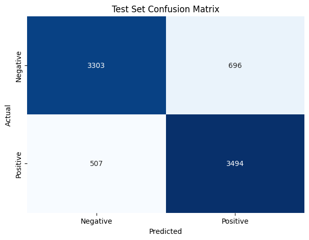

```python
from sklearn.metrics import confusion_matrix
import seaborn as sns
import matplotlib.pyplot as plt

model.eval()
y_true, y_pred = [], []

# Get predictions for the entire test set
with torch.no_grad():
    for reviews, labels in test_loader:
        reviews = reviews.to(DEVICE)

        hidden = model.init_hidden(reviews.size(0))
        output, _ = model(reviews, hidden)

        preds = torch.round(output.squeeze()).cpu().numpy()
        y_pred.extend(preds)
        y_true.extend(labels.numpy())

# Plot confusion matrix
cm = confusion_matrix(y_true, y_pred)

plt.figure(figsize=(7, 5))
sns.heatmap(cm, annot=True, fmt='d', cmap='Blues',
            xticklabels=['Negative', 'Positive'],
            yticklabels=['Negative', 'Positive'],
            cbar=False)

plt.xlabel('Predicted')
plt.ylabel('Actual')
plt.title('Test Set Confusion Matrix')
plt.show()
```

```python
'''
PROVIDE YOUR ANSWER BELOW

False Positive: these 3 comments are all predicted as postive, but they are actually negative comments,

    1: This review mixes mild expressions (some of the acting is good
    and okay as drama) with an overall disappointed conclusion. The LSTM likely focused on
    those local positive phrases and underweighted the broader negative judgment. This looks
    like a sentiment-flip error.

    2: While the review contains "Disappointing" at the beginning, the rest of the review rarely contains
       any negative words. Even positive words like "glorify" and "sportsmanship" are included. However,
       the negative words are not explicitly used. Instead, neutral words are used to criticize.
       This error is not clearly considered under the common LSTM weaknesses listed in the question.
       Instead, it is more likely due to subtle and context-dependent criticism, which the LSTM
       may have struggled to interpret correctly.


    3: This review also includes a few positive expression such as "much better" and "one cool thing".
       The model seems to have overreacted to those small positive cues and missed the repeated negative words like
       "awful", "dull".


False Negative: these reviews are all predicted as negative, but they are actually positive comments,


    1: This review has many spelling mistakes and almost no punctuation. And the positive meaning is spread
       across the whole passage. The LSTM might struggle to preserve it over such a noisy sequence.
       This is a long-dependency error.

    2: The reviewer used many negative words, such as “destroy,” “terrorists,” “evil,” but these words seem to be used
       to describe the movie rather as comment. The model may confused negative words and predict this as a negative sentiment.
       This is considered a context misunderstanding.

    3: This review contains strongly positive words like “intelligent,” “witty,” “hilarious,” and “refreshing.”,
       but it also contains phrases like "What a shame!", criticism of marketing, and a comparison against another weak movie.
       Those side comments may have dominated the prediction even though the main opinion is very favorable.
       Therefore, this is a sentiment flipping error.



'''
```

### Part (iii) [2pt RESULT]

What is your model's prediction of the **probability** that the review message provided below is a positive review?

Hint: You will need to apply the same processing on the review as was done on the the train, val, and test data sets.

```python
review = """ Man.... I wish I loved this movie more than I did. Don't get me wrong,
it's a solid action movie with jaw-dropping stunts (some of the best in the series),
but as a Mission: Impossible movie, it felt like a small step backward for the franchise.
Fallout had mind-blowing action sequences and stunt work, along with developing Ethan's
relationship with Ilsa, providing closure with Julia, showing the lengths Ethan would
go to protect those closest to him, and battling an imposing villain. Dead Reckoning:
Part One stretches the movie across two films only to seemingly showcase action
spectacle after action spectacle while sacrificing character development.
Characters I have grown to love over a decade of films felt sidelined, ignored,
or wasted. Hayley Atwell's new character chewed up most of the screen time, and
while she was fantastic, I wanted to see more of the original team. The new villain
had an inconsistent ability that confused more than intimidated. There were some
important emotional moments that I just didn't feel the weight of when I definitely
should have. Part Two might tie everything together and make me enjoy Part One
more in retrospect, but unfortunately, I left wanting more from this one. """
```

```python
# Convert the raw text to a list of integer tokens using the existing stoi dictionary
encoded_review = [stoi[word] for word in preprocess_sentence(review) if word in stoi.keys()]
```

```python
# Pad the tokenized review to the exact same SEQ_LEN (500) used during training
# padding_ function expects a list of sentences, so we wrap it in a list
padded_review = padding_([encoded_review], SEQ_LEN)
```

```python
#Convert to Tensor and Model Inference
model.eval()

# Convert to PyTorch LongTensor and move to the correct device
review_tensor = torch.from_numpy(padded_review).long().to(DEVICE)

with torch.no_grad():
    # Initialize hidden state for a batch size of 1
    hidden = model.init_hidden(1)

    # Forward pass through the model
    output, _ = model(review_tensor, hidden)

    # The output is directly the probability (since we use Sigmoid in our model)
    prediction_prob = output.item()

# Display the Result
print(f"Predicted Probability of being Positive: {prediction_prob:.4f}")
if prediction_prob >= 0.5:
    print("Model Prediction: POSITIVE \U0001f44d")
else:
    print("Model Prediction: NEGATIVE \U0001f44e")
```

```
Predicted Probability of being Positive: 0.4144
Model Prediction: NEGATIVE 👎
```

### Part (iv) [2pt DISCUSSION]

Do you think that detecting positive and negative reviews is an easy or difficult task?

Since machine learning models are expensive to train and deploy, it is very important to compare our models against baseline models: a simple model that is easy to build and inexpensive to run that we can compare our recurrent neural network model against.

Explain how you might build a simple baseline model. This baseline model can be a simple neural network (with very few weights), a hand-written algorithm, or any other strategy that is easy to build and test.

**Do not actually build a baseline model. Instead, provide instructions on how to build it.**

```python
'''
PROVIDE YOUR ANSWER BELOW

If only detecting positive and negative reviews is not a completely easy task.
There are reviews in which sentiment words are clear, and hence it is a relatively easier task to classify them
into a certain group, but there are reviews are mixed as we saw above, negation is used, or there are long passages
in which the sentiment depends on the context. Therefore, I would consider it a moderately difficult task
rather than a simple task.

One possible approach to a baseline model is a straightforward bag of words with logistic regression.
The first step would be to preprocess the reviews in the same manner as the training data, such as converting
all the text to lowercase and splitting it into words. The second step would be to convert the reviews into a
bag of words and train a logistic regression classifier on the reviews to predict
whether the review is positive or negative. The third step would be to test the baseline model on the validation
and test data and compare the results with the LSTM model. This approach would be much cheaper and easier to train
than the LSTM approach but would not perform as well.




'''
```

# PART B - Transfer Learning

For many natural language processing tasks, it is generally not a good idea to train a very large deep neural network model from scratch due to enormous compute requirements and lack of sufficient amounts of training data. Instead, you should always try to take advantage of an existing model that performs similar tasks as the one you need to solve.

In this part of the assignment we will be using pretrained models to improve the performance on identifying positive and negative reviews. There are several pretrained models that are available to us, here we will use a pretrained BERT model that comes with the hugging face transformer library.

Provided below is sample code to get you started. For more details please visit the hugging face tutorial on using pretrained models using PyTorch: https://huggingface.co/docs/transformers/training

#### Sample Code

```python
# install relevant libraries
!pip install -qq transformers
```

```python
# load relevant libraries
import transformers
from transformers import BertModel, BertTokenizer, get_linear_schedule_with_warmup
from torch.optim import AdamW

PRE_TRAINED_MODEL_NAME = 'bert-base-cased'

tokenizer = BertTokenizer.from_pretrained(PRE_TRAINED_MODEL_NAME)
bert_model = BertModel.from_pretrained(PRE_TRAINED_MODEL_NAME)

################### SUBMISSION NOTE ####################################
#  - output of this cell creates issues for converting ipynb to HTML
#  - you may want to delete this output when you are ready to submit
```

```python
sample_txt = 'I want to learn how to do sentiment analysis using BERT and tokenizer.'

encoding = tokenizer(
  sample_txt,
  max_length=32,
  add_special_tokens=True, # Add '[CLS]' and '[SEP]'
  return_token_type_ids=False,
  padding="max_length",
  return_attention_mask=True,
  return_tensors='pt',  # Return PyTorch tensors
  truncation = True
)
```

```python
encoding['input_ids']
```

```
tensor([[  101,   146,  1328,  1106,  3858,  1293,  1106,  1202, 17024,  3622,
          1606,   139,  9637,  1942,  1105, 22559, 17260,   119,   102,     0,
             0,     0,     0,     0,     0,     0,     0,     0,     0,     0,
             0,     0]])
```

```python
encoding['attention_mask']
```

```
tensor([[1, 1, 1, 1, 1, 1, 1, 1, 1, 1, 1, 1, 1, 1, 1, 1, 1, 1, 1, 0, 0, 0, 0, 0,
         0, 0, 0, 0, 0, 0, 0, 0]])
```

```python
hidden_states = bert_model(input_ids=encoding['input_ids'],
                           attention_mask=encoding['attention_mask'])[0]
pooled_output = bert_model(input_ids=encoding['input_ids'],
                           attention_mask=encoding['attention_mask'])[1]
```

```python
hidden_size = bert_model.config.hidden_size

print(hidden_size)
print(hidden_states.shape)
print(pooled_output.shape)
```

```
768
torch.Size([1, 32, 768])
torch.Size([1, 768])
```

In the sample code provided we loaded a short text sequence, tokenized it using the same tokenization that was used in the pretrained BERT model, and fed the tokenized input into the BERT model to obtain the embeddings.

The model output consists of two forms of embeddings:

- **hidden_states** are the final layer of outputs that has a shape sequence_length x embeddings, much like the hidden states of a recurrent neural network
- **pooled_output** is the result of applying max pooling on the hidden states to effectively collapse the sequence dimenension and ensure the same output size for any given sequence before feeding into the classification stage

Note that you can preprocess all of the data prior to training a classifier stage for sentiment analysis to help speed up the training process. This is no different from the process we applied in an earlier assignment using AlexNet and image data.

## Part 1. Data Loading [5 pt]

We will be using the same "IMDB Movie Review Dataset" that we used earlier. Reload the data and complete Part B of the assignment. You should be able to complete part B independently from Part A.

### Part (i) [1pt EXPLORATORY]

Provided below is a DataLoader for your training and test datasets so you can iterate over batches of data. Run the DataLoader to create your training, validation, and test data.

```python
from torch.utils.data import Dataset, DataLoader

class MovieReviewDataset(Dataset):

  def __init__(self, reviews, targets, tokenizer, max_len):
    self.reviews = reviews
    self.targets = targets
    self.tokenizer = tokenizer
    self.max_len = max_len

  def __len__(self):
    return len(self.reviews)

  def __getitem__(self, item):
    review = str(self.reviews[item])
    #obtain numerical labels
    target = 1 if self.targets[item] == 'positive' else 0

    encoding = self.tokenizer(
      review,
      add_special_tokens=True,
      max_length=self.max_len,
      return_token_type_ids=False,
      padding="max_length",
      return_attention_mask=True,
      return_tensors='pt',
      truncation = True
    )

    return {
      'review_text': review,
      'input_ids': encoding['input_ids'].flatten(),
      'attention_mask': encoding['attention_mask'].flatten(),
      'targets': torch.tensor(target, dtype=torch.long)
    }
```

```python
import pandas as pd
from sklearn.model_selection import train_test_split

# Reload data for independent Part B execution
df = pd.read_csv("IMDB Dataset.csv")

# 60-20-20 split
df_train, df_temp = train_test_split(df, test_size=0.4, random_state=42, stratify=df['sentiment'])
df_val, df_test = train_test_split(df_temp, test_size=0.5, random_state=42, stratify=df_temp['sentiment'])

print(f" Train: {len(df_train)} | Val: {len(df_val)} | Test: {len(df_test)}")

MAX_LEN = 400
BATCH_SIZE = 16

def create_loader(data_df, tokenizer, max_len, batch_size):
    """Helper to generate PyTorch DataLoader"""
    ds = MovieReviewDataset(
        reviews=data_df['review'].to_numpy(),
        targets=data_df['sentiment'].to_numpy(),
        tokenizer=tokenizer,
        max_len=max_len
    )
    return DataLoader(ds, batch_size=batch_size, num_workers=2)

train_data_loader = create_loader(df_train, tokenizer, MAX_LEN, BATCH_SIZE)
val_data_loader = create_loader(df_val, tokenizer, MAX_LEN, BATCH_SIZE)
test_data_loader = create_loader(df_test, tokenizer, MAX_LEN, BATCH_SIZE)
```

```
 Train: 24000 | Val: 8000 | Test: 8000
```

### Part (ii) [1pt EXPLORATORY]

Use the **train_data_loader** to load one sample. What are the different attributes provided with the sample and how are they used?

```python
# TO BE COMPLETED

# Fetch one batch from the training data loader
sample_batch = next(iter(train_data_loader))

# Print the attributes (keys) provided with the sample
print("Attributes provided in the sample:")
print(list(sample_batch.keys()))

# Print details for each attribute to understand how they are used
print("\nDetails for each attribute:")
for key, value in sample_batch.items():
    if hasattr(value, 'shape'):
        print(f"- {key}: Tensor with shape {value.shape}, dtype {value.dtype}")
    else:
        print(f"- {key}: {type(value)} with length {len(value)}")
```

```
Attributes provided in the sample:
['review_text', 'input_ids', 'attention_mask', 'targets']

Details for each attribute:
- review_text: <class 'list'> with length 16
- input_ids: Tensor with shape torch.Size([16, 400]), dtype torch.int64
- attention_mask: Tensor with shape torch.Size([16, 400]), dtype torch.int64
- targets: Tensor with shape torch.Size([16]), dtype torch.int64
```

```python
'''
PROVIDE YOUR ANSWER BELOW


The sample has four attributes: review_text, input_ids, attention_mask, and targets.

review_text has the actual review text for reference.
input_ids has the tokenized reviews in integer form, which are then passed to the model.
attention_mask indicates to the model what are actual tokens and what are padding.
targets has the actual sentiment label.



'''
```

### Part (iii) [1pt EXPLORATORY]

Determine the range of values for the tokens in the training data. How are the tokens obtained?

Also identify the role of at least three special tokens used by the tokenizer (for example, padding, separator, classification, or unknown tokens).

Hint: You can apply your intuition here, or do some additional research to find how the "bert-base-cased" tokenization is done.

```python
# TO BE COMPLETED

min_token_val = float('inf')
max_token_val = float('-inf')

for batch in train_data_loader:
    min_val = batch['input_ids'].min().item()
    max_val = batch['input_ids'].max().item()

    if min_val < min_token_val:
        min_token_val = min_val
    if max_val > max_token_val:
        max_token_val = max_val

print(f"Token values in the training data range from {min_token_val} to {max_token_val}.")
print(f"Total tokenizer vocabulary size: {tokenizer.vocab_size}\n")

# Identify the special tokens used by the tokenizer
print("Special Tokens used by 'bert-base-cased':")
for token_name, token_id in zip(tokenizer.all_special_tokens, tokenizer.all_special_ids):
    print(f"- {token_name}: ID {token_id}")
```

```
Token values in the training data range from 0 to 28223.
Total tokenizer vocabulary size: 28996

Special Tokens used by 'bert-base-cased':
- [UNK]: ID 100
- [SEP]: ID 102
- [PAD]: ID 0
- [CLS]: ID 101
- [MASK]: ID 103
```

```python
'''
PROVIDE YOUR ANSWER BELOW

The range of token values in the training data is from 0 to 28223, while the total vocabulary size for the bert-base-cased
tokenizer is 28996. This shows that not all words in the vocabulary are available in the training data.

The tokens are obtained by passing the raw review data through the pretrained bert-base-cased tokenizer.
This tokenizer performs wordpiece tokenization, which breaks the input text into subword units and assigns an integer
value to each token or subword in the input text from the tokenizer’s vocabulary.
It also adds special tokens such as [CLS] and [SEP] to the input text and pads the input text to a specified length.


Some important special tokens are:
	•	[PAD] (ID 0): used to pad shorter sequences to a fixed length so they can be processed in batches.
	•	[CLS] (ID 101): added at the beginning of the sequence and used by BERT as the main representation for classification tasks.
	•	[SEP] (ID 102): used to mark the end of a sentence or separate two sentences.
	•	[UNK] (ID 100): used for unknown tokens that cannot be represented directly.
	•	[MASK] (ID 103): used mainly during BERT pretraining for masked language modeling.





'''
```

### Part (iv) [1pt EXPLORATORY]

Generate histograms of all the token values in the training data. Repeat for the validation and test data. What are the top 5 occuring tokens in the training_dataset? What do these tokens represent?

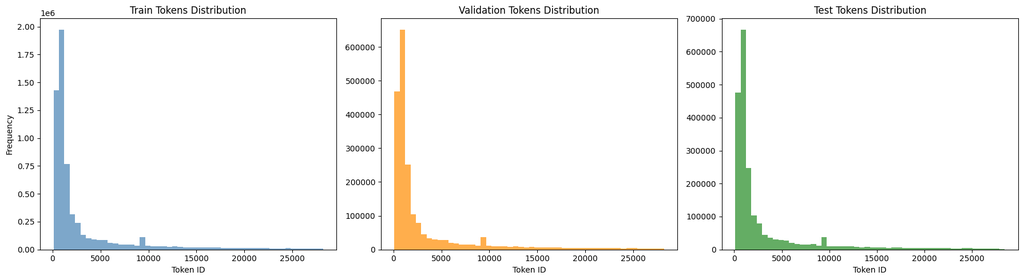

```
Top 5 tokens in training set (excluding [PAD]):
ID 119   | String: '.    ' | Count: 256667
ID 1103  | String: 'the  ' | Count: 222384
ID 117   | String: ',    ' | Count: 208733
ID 170   | String: 'a    ' | Count: 123328
ID 1105  | String: 'and  ' | Count: 120800
```

```python
import matplotlib.pyplot as plt
from collections import Counter
import numpy as np

# Helper to extract all non-pad token IDs
def extract_tokens(loader):
    tokens = []
    for batch in loader:
        ids = batch['input_ids'].flatten().numpy()
        tokens.extend(ids[ids != 0])  # Ignore [PAD] = 0
    return tokens

print("Collecting tokens")
train_tokens = extract_tokens(train_data_loader)
val_tokens = extract_tokens(val_data_loader)
test_tokens = extract_tokens(test_data_loader)

# Plot distributions cleanly using a loop
fig, axes = plt.subplots(1, 3, figsize=(18, 5))
datasets = [
    ('Train', train_tokens, 'steelblue'),
    ('Validation', val_tokens, 'darkorange'),
    ('Test', test_tokens, 'forestgreen')
]

for ax, (name, tokens, color) in zip(axes, datasets):
    ax.hist(tokens, bins=50, color=color, alpha=0.7)
    ax.set_title(f'{name} Tokens Distribution')
    ax.set_xlabel('Token ID')
    if name == 'Train':
        ax.set_ylabel('Frequency')

plt.tight_layout()
plt.show()

# Get top 5 most frequent tokens
top_5 = Counter(train_tokens).most_common(5)
print("\nTop 5 tokens in training set (excluding [PAD]):")
for token_id, count in top_5:
    token_str = tokenizer.convert_ids_to_tokens(int(token_id))
    print(f"ID {token_id:<5} | String: '{token_str:<5}' | Count: {count}")
```

```python
'''
PROVIDE YOUR ANSWER BELOW

The token histograms for the train, validation, and test splits are very similar, which
is pretty much what I would expect because all three splits come from the same IMDB corpus and use the
same tokenizer.


The most frequent tokens in the training set are '.' , 'the', ',' , 'a', and 'and'.
This makes sense, as these tokens are punctuation marks and very frequent English function words.
They play a role in building sentence structure, but tend to have less sentiment information compared
to words like adjectives or opinion-related words.




'''
```

### Part (v) [1pt EXPLORATORY]

Select a single sample from your training DataLoader and feed it through the **bert_model** to obtain the hidden_states and pooled_output. Briefly describe what each tensor dimension represents and what affects the size of each dimension.

```python
# Fetch a single batch and slice out the first sample
batch = next(iter(train_data_loader))

# Keep the batch dimension by slicing [0:1] instead of [0]
input_ids = batch['input_ids'][0:1]
attention_mask = batch['attention_mask'][0:1]

# Pass the sample through the BERT model
bert_model.eval()
with torch.no_grad():
    outputs = bert_model(input_ids=input_ids, attention_mask=attention_mask)

    # Extract hidden states and pooled output
    hidden_states = outputs[0]
    pooled_output = outputs[1]

print(f"input_ids shape:{input_ids.shape}")
print(f"hidden_states shape: {hidden_states.shape}")
print(f"pooled_output shape: {pooled_output.shape}")
```

```
input_ids shape:torch.Size([1, 400])
hidden_states shape: torch.Size([1, 400, 768])
pooled_output shape: torch.Size([1, 768])
```

```python
'''
PROVIDE YOUR ANSWER BELOW

The input_ids has shape [1, 400]:
  The first dimension is the batch size of 1 because only one sample was selected.
  The second dimension is the sequence length of 400 because the review was tokenized and
  padded to a maximum length of 400 tokens.




hidden_states shape as[1, 400, 768]:
  The first dimension is the batch size. The second dimension refers to the token positions in the input sequence.
  There are contextual embeddings same as tokens in the input sequence (400 tokens).
  The third dimension is the hidden size of BERT, and the hidden size for bert-base-cased is 768.


pooled_output shape as [1, 768]:
  The first one is still batch size. The second one is hidden size, which is 768.
  This is the pooled [CLS] representation used for whole-review classification.



'''
```

## Part 2. Model Architecture [2 pt]

### Part (i) [1pt MODEL]

Prepare a review classifier model that builds on the pooled output from the Bert model to identify positive and negative reviews.

```python
class SentimentClassifierPooled(nn.Module):

  def __init__(self, n_classes):
    super(SentimentClassifierPooled, self).__init__()
    self.bert = BertModel.from_pretrained(PRE_TRAINED_MODEL_NAME)

    # TO BE COMPLETED
    self.drop = nn.Dropout(p=0.3)
    self.out = nn.Linear(self.bert.config.hidden_size, n_classes)
    self.sig = nn.Sigmoid()

  def forward(self, input_ids, attention_mask):
    pooled_output = self.bert(input_ids=input_ids, attention_mask=attention_mask)[1]

    # TO BE COMPLETED
    output = self.drop(pooled_output)
    output = self.out(output)
    return self.sig(output)
```

### Part (ii) [1pt MODEL]

Construct the architecture for a review classifier model that uses the last hidden output from the Bert model to identify positive and negative reviews.

```python
class SentimentClassifierLast(nn.Module):

  def __init__(self, n_classes):
    super(SentimentClassifierLast, self).__init__()
    self.bert = BertModel.from_pretrained(PRE_TRAINED_MODEL_NAME)

    # TO BE COMPLETED
    self.drop = nn.Dropout(p=0.3)
    self.out = nn.Linear(self.bert.config.hidden_size, n_classes)
    self.sig = nn.Sigmoid()

  def forward(self, input_ids, attention_mask):

    # TO BE COMPLETED

    # outputs[0] contains the hidden states of all tokens in the last layer
    hidden_states = self.bert(input_ids=input_ids, attention_mask=attention_mask)[0]

    cls_hidden_state = hidden_states[:, 0, :]

    output = self.drop(cls_hidden_state)
    output = self.out(output)
    return self.sig(output)
```

## Part 3. Training [3 pt]

### Part (i) [1pt MODEL]

Complete the `get_accuracy` function, which will compute the accuracy (rate) of your model across a dataset (e.g. validation set).

```python
def get_accuracy(model, data):
    """ Compute the accuracy of the `model` across a dataset `data`

    Example usage:

    >>> model = MyRNN() # to be defined
    >>> get_accuracy(model, valid_loader) # the variable `valid_loader` is from above
    """

    # TO BE COMPLETED
    correct, total = 0, 0
    model.eval()

    with torch.no_grad():
        for batch in data:
            # Extract data from the dictionary returned by MovieReviewDataset
            input_ids = batch['input_ids'].to(DEVICE)
            attention_mask = batch['attention_mask'].to(DEVICE)
            targets = batch['targets'].to(DEVICE)

            # Forward pass
            outputs = model(input_ids=input_ids, attention_mask=attention_mask)

            # Convert probabilities to binary predictions (0 or 1)
            preds = torch.round(outputs.squeeze())

            # Calculate accuracy
            correct += preds.eq(targets.view_as(preds)).sum().item()
            total += targets.size(0)

    model.train() # Restore training mode
    return correct / total
```

### Part (ii) [1pt MODEL]

Write a function **train_model** to train your model. Plot the training curve of your final model. Your training curve should have the training/validation loss and accuracy plotted periodically.

Save the best model checkpoint based on validation accuracy so that you can reload it later if your notebook runtime restarts. You can follow the same pattern from Part A but use different filenames.

```python
def train_model(model, train_loader, val_loader, learning_rate=2e-5, num_epochs=3, checkpoint_name="bert_best.pt", show_plot=True):
    """
    Train the BERT-based model and optionally plot the training curves.
    Returns the best validation accuracy achieved.
    """

    criterion = nn.BCELoss()
    optimizer = AdamW(model.parameters(), lr=learning_rate)

    best_val_acc = 0.0
    train_losses, val_losses = [], []
    train_accs, val_accs = [], []

    print("Starting BERT training...")
    for epoch in range(num_epochs):
        #  Training Phase
        model.train()
        total_train_loss = 0.0
        correct_train = 0
        total_train = 0

        for batch in train_loader:
            input_ids = batch['input_ids'].to(DEVICE)
            attention_mask = batch['attention_mask'].to(DEVICE)
            targets = batch['targets'].to(DEVICE).float()

            optimizer.zero_grad()

            # Forward pass (BERT doesn't need hidden state initialization)
            outputs = model(input_ids=input_ids, attention_mask=attention_mask)

            # Calculate loss
            loss = criterion(outputs.squeeze(), targets)
            loss.backward()

            # Clip gradients (standard practice for transformer models)
            nn.utils.clip_grad_norm_(model.parameters(), max_norm=1.0)
            optimizer.step()

            total_train_loss += loss.item() * targets.size(0)

            # Calculate accuracy
            preds = torch.round(outputs.squeeze())
            correct_train += preds.eq(targets.view_as(preds)).sum().item()
            total_train += targets.size(0)

        train_loss = total_train_loss / total_train
        train_acc = correct_train / total_train

        #  Validation Phase
        model.eval()
        total_val_loss = 0.0
        correct_val = 0
        total_val = 0

        with torch.no_grad():
            for batch in val_loader:
                input_ids = batch['input_ids'].to(DEVICE)
                attention_mask = batch['attention_mask'].to(DEVICE)
                targets = batch['targets'].to(DEVICE).float()

                outputs = model(input_ids=input_ids, attention_mask=attention_mask)

                loss = criterion(outputs.squeeze(), targets)
                total_val_loss += loss.item() * targets.size(0)

                preds = torch.round(outputs.squeeze())
                correct_val += preds.eq(targets.view_as(preds)).sum().item()
                total_val += targets.size(0)

        val_loss = total_val_loss / total_val
        val_acc = correct_val / total_val

        train_losses.append(train_loss)
        val_losses.append(val_loss)
        train_accs.append(train_acc)
        val_accs.append(val_acc)

        print(f"Epoch {epoch+1}/{num_epochs} | Train Loss: {train_loss:.4f} | Train Acc: {train_acc:.4f} | Val Loss: {val_loss:.4f} | Val Acc: {val_acc:.4f}")

        # Save best checkpoint
        if val_acc > best_val_acc:
            best_val_acc = val_acc
            save_checkpoint(
                os.path.join(CHECKPOINT_DIR, checkpoint_name),
                model,
                optimizer=optimizer,
                epoch=epoch,
                best_val_acc=best_val_acc
            )
            print(f"Saved best BERT checkpoint at epoch {epoch+1} with acc: {best_val_acc:.4f}")

    #  Plotting the training curves
    if show_plot:
        import matplotlib.pyplot as plt
        plt.figure(figsize=(12, 5))

        plt.subplot(1, 2, 1)
        plt.plot(range(1, num_epochs+1), train_losses, label='Train Loss')
        plt.plot(range(1, num_epochs+1), val_losses, label='Val Loss')
        plt.title('Training and Validation Loss')
        plt.xlabel('Epochs')
        plt.ylabel('Loss')
        plt.legend()

        plt.subplot(1, 2, 2)
        plt.plot(range(1, num_epochs+1), train_accs, label='Train Accuracy')
        plt.plot(range(1, num_epochs+1), val_accs, label='Val Accuracy')
        plt.title('Training and Validation Accuracy')
        plt.xlabel('Epochs')
        plt.ylabel('Accuracy')
        plt.legend()

        plt.tight_layout()
        plt.show()

    return best_val_acc
```

### Part (iii) [1pt MODEL]

Choose at least 4 hyperparameters to tune. Explain how you tuned the hyperparameters. You don't need to include your training curve for every model you trained. Instead, explain what hyperparemters you tuned, what the best validation accuracy was, and the reasoning behind the hyperparameter decisions you made.

For this assignment, you should tune more than just your learning rate and epoch. Choose at least 2 hyperparameters that are unrelated to the optimizer.

```
[Widget Output Removed]
```

[output not shown]

```
Starting BERT training...
Saved best BERT checkpoint at epoch 1 with acc: 0.9233
Saved best BERT checkpoint at epoch 2 with acc: 0.9245
Saved best BERT checkpoint at epoch 3 with acc: 0.9276
```

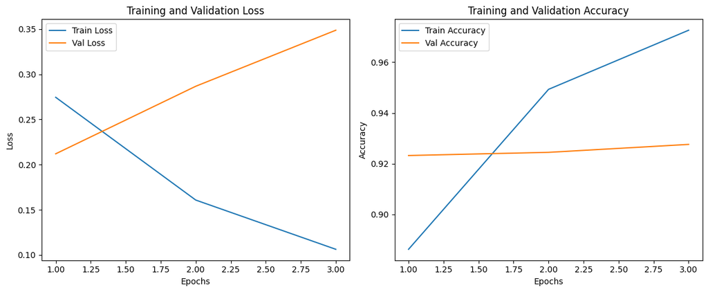

```
Best Validation Accuracy for LR=1e-5: 0.9276
```

```python
# model1: Learning Rate = 1e-5


model = SentimentClassifierLast(n_classes=1).to(DEVICE)
acc_lr1 = train_model(
    model=model,
    train_loader=train_data_loader,
    val_loader=val_data_loader,
    learning_rate=1e-5,
    num_epochs=3,
    checkpoint_name="bert_lr1e5.pt",
    show_plot=True
)

print(f"\nBest Validation Accuracy for LR=1e-5: {acc_lr1:.4f}")
```

```
[Widget Output Removed]
```

[output not shown]

```
Starting BERT training...
Saved best BERT checkpoint at epoch 1 with acc: 0.9104
Saved best BERT checkpoint at epoch 2 with acc: 0.9133
```

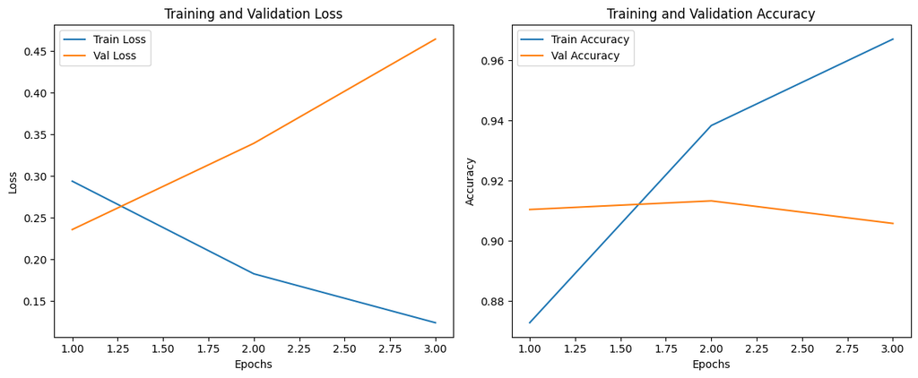

```
Best Validation Accuracy for max_len=256: 0.9133
```

```python
# model2: max_len = 256
new_max_len = 256
batch_size = 16

tune_train_loader = create_loader(df_train, tokenizer, new_max_len, batch_size)
tune_val_loader = create_loader(df_val, tokenizer, new_max_len, batch_size)

model_maxlen = SentimentClassifierLast(n_classes=1).to(DEVICE)
acc_maxlen = train_model(
    model=model_maxlen,
    train_loader=tune_train_loader,
    val_loader=tune_val_loader,
    learning_rate=1e-5,
    num_epochs=3,
    checkpoint_name=f"bert_maxlen_{new_max_len}.pt",
    show_plot=True
)

print(f"\nBest Validation Accuracy for max_len={new_max_len}: {acc_maxlen:.4f}")
```

```
[Widget Output Removed]
```

[output not shown]

```
Freezing the first 6 layers of BERT...
Starting BERT training...
Saved best BERT checkpoint at epoch 1 with acc: 0.9173
Saved best BERT checkpoint at epoch 2 with acc: 0.9197
Saved best BERT checkpoint at epoch 3 with acc: 0.9259
```

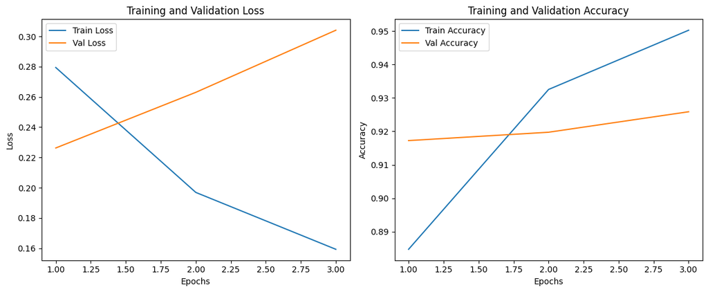

```
Best Validation Accuracy for max_len=400 and 6 layers frozen: 0.9259
```

```python
# model3: Tuning Freeze Layers = 6
new_max_len = 400
batch_size = 16
freeze_layers_count = 6

tune_train_loader = create_loader(df_train, tokenizer, new_max_len, batch_size)
tune_val_loader = create_loader(df_val, tokenizer, new_max_len, batch_size)


model_maxlen = SentimentClassifierLast(n_classes=1).to(DEVICE)


if freeze_layers_count > 0:
    print(f"Freezing the first {freeze_layers_count} layers of BERT...")
    for param in model_maxlen.bert.embeddings.parameters():
        param.requires_grad = False


    for i in range(min(freeze_layers_count, 12)):
        for param in model_maxlen.bert.encoder.layer[i].parameters():
            param.requires_grad = False


acc_maxlen = train_model(
    model=model_maxlen,
    train_loader=tune_train_loader,
    val_loader=tune_val_loader,
    learning_rate=1e-5,
    num_epochs=3,
    checkpoint_name=f"bert_frozen_{freeze_layers_count}.pt",
    show_plot=True
)

print(f"\nBest Validation Accuracy for max_len={new_max_len} and {freeze_layers_count} layers frozen: {acc_maxlen:.4f}")
```

```
[Widget Output Removed]
```

[output not shown]

```
Starting BERT training...
Saved best BERT checkpoint at epoch 1 with acc: 0.9184
Saved best BERT checkpoint at epoch 2 with acc: 0.9227
Saved best BERT checkpoint at epoch 3 with acc: 0.9256
```

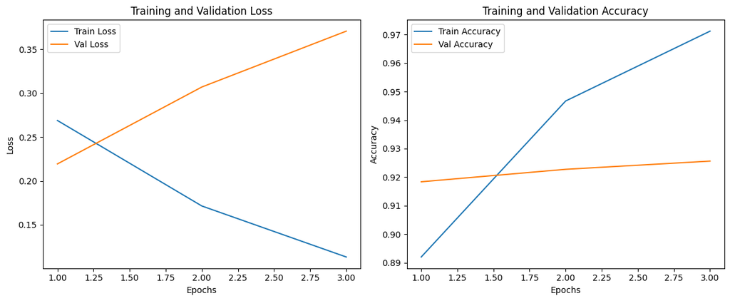

```
Final Result: Acc: 0.9256 | Config: {'max_len': 400, 'batch_size': 16, 'freeze_layers': 0, 'lr': 1e-05, 'dropout': 0.5, 'epochs': 3}
```

```python
#model 4: dropout Prob = 0.5
config = {
    'max_len': 400,
    'batch_size': 16,
    'freeze_layers': 0,
    'lr': 1e-5,
    'dropout': 0.5,
    'epochs': 3
}

train_loader = create_loader(df_train, tokenizer, config['max_len'], config['batch_size'])
val_loader = create_loader(df_val, tokenizer, config['max_len'], config['batch_size'])

model = SentimentClassifierLast(n_classes=1).to(DEVICE)
model.drop.p = config['dropout']

# Layer freezing
if config['freeze_layers'] > 0:
    for param in model.bert.embeddings.parameters():
        param.requires_grad = False
    for i in range(min(config['freeze_layers'], 12)):
        for param in model.bert.encoder.layer[i].parameters():
            param.requires_grad = False

# Execution
ckpt_name = f"bert_frozen_{config['freeze_layers']}_drop{str(config['dropout']).replace('.', '')}.pt"
best_acc = train_model(
    model=model,
    train_loader=train_loader,
    val_loader=val_loader,
    learning_rate=config['lr'],
    num_epochs=config['epochs'],
    checkpoint_name=ckpt_name
)

print(f"\nFinal Result: Acc: {best_acc:.4f} | Config: {config}")
```

```
[Widget Output Removed]
```

[output not shown]

```
Starting BERT training...
Saved best BERT checkpoint at epoch 1 with acc: 0.9165
Saved best BERT checkpoint at epoch 2 with acc: 0.9220
Saved best BERT checkpoint at epoch 3 with acc: 0.9234
```

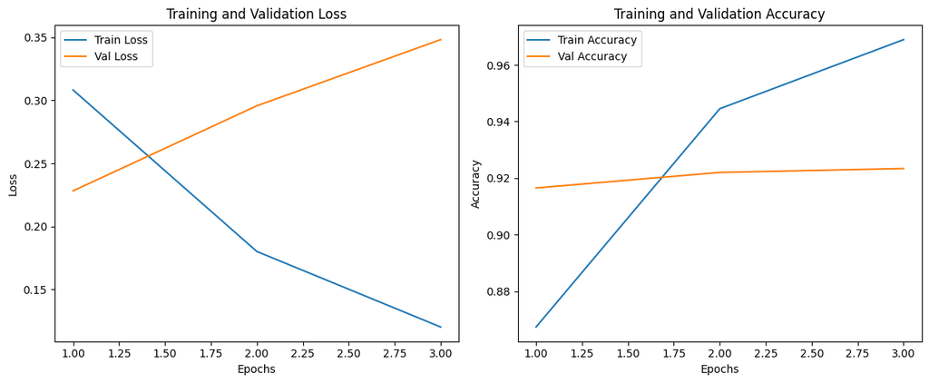

```
Final Result: Acc: 0.9234 | Config: {'max_len': 400, 'batch_size': 16, 'freeze_layers': 0, 'lr': 1e-05, 'dropout': 0.7, 'epochs': 3}
```

```python
#model 5: dropout prob = 0.7
config = {
    'max_len': 400,
    'batch_size': 16,
    'freeze_layers': 0,
    'lr': 1e-5,
    'dropout': 0.7,
    'epochs': 3
}

train_loader = create_loader(df_train, tokenizer, config['max_len'], config['batch_size'])
val_loader = create_loader(df_val, tokenizer, config['max_len'], config['batch_size'])

model = SentimentClassifierLast(n_classes=1).to(DEVICE)
model.drop.p = config['dropout']

ckpt_name = f"bert_drop{str(config['dropout']).replace('.', '')}.pt"
best_acc = train_model(
    model=model,
    train_loader=train_loader,
    val_loader=val_loader,
    learning_rate=config['lr'],
    num_epochs=config['epochs'],
    checkpoint_name=ckpt_name
)

print(f"\nFinal Result: Acc: {best_acc:.4f} | Config: {config}")
```

```python
'''
PROVIDE YOUR ANSWER BELOW

I chose Learning Rate, Max Length, Dropout Probability, Number of Freeze Layers for the hyperparameters tuning
All tuning models have the same epoch = 3


Model 1: (lr = 1e-5, max_length = 400, dropout = 0.3) achieved the best validation acc 0.9276

Model2:  I tied reduded max_len to 256, while keeping others unchanged. But the validation accuracy dropped to 0.9133
This suggest that the IMDB review could be length, reducing the max_len limited the model to capture the
important sentiment information from the reviews

Model3: I kept lr = 1e-5 and max_len = 400, but tuned freeze_layers = 6 since the model 1 has overfitting tendncy,
freezing some of the early layers reduces the number of trainable parameters and can help regularize the model, improve training
stability. However, this model acheived best val acc: 0.9259, which is lower than model 1.
This suggest that the IMDB dataset was enough and can benefit from the full fine-tuning stage.

Model 4: The baseline model 1 used a dropout probability of 0.3; increasing it to 0.5 here was to test whether stronger
regularization could reduce overfitting and improve generalization. This model achieved best val acc: 0.9256, which is still
lower than model 1. Simialr, for model 5, when the dropout probability of 0.7 applied, the best val acc for model5 was 0.9234
The two models suggest that increasing the regulization for the model was not helpful,

Overall, the best-performing configuration was Model 1:
  learning rate = 1e-5,
  max_length = 400,
  dropout = 0.3,
  no frozen layers,
  and 3 epochs.


'''
```

## Part 4. Evaluation [10 pt]

### Part (i) [3pt RESULT]

Report the final test accuracy of your best BERT-based model. Then summarize in a Pandas DataFrame the accuracy obtained on the training, validation, and test data of your best models from Part A and B.

How does the BERT model compare to the approach in part A using only LSTM? Are the results what you expected? Explain.

```python
import os
import torch


DEVICE = torch.device("cuda" if torch.cuda.is_available() else "cpu")

CHECKPOINT_DIR_pb4 = "/content"
weights_path = os.path.join(CHECKPOINT_DIR_pb4, 'bert_lr1e5.pt')

model = SentimentClassifierLast(n_classes=1).to(DEVICE)

if os.path.exists(weights_path):
    # Manually loading
    checkpoint = torch.load(weights_path, map_location=DEVICE)
    model.load_state_dict(checkpoint['model_state_dict'])
    model.eval()
    print(f"Successfully loaded: {weights_path} on {DEVICE}")

    test_acc_bert = get_accuracy(model, test_data_loader)
    print(f"BERT Test Acc: {test_acc_bert:.4f}")
else:
    print(f"Weights not found at {weights_path}.")
```

```
[Widget Output Removed]
```

[output not shown]

```
Successfully loaded: /content/bert_lr1e5.pt on cuda
BERT Test Acc: 0.9275
```

```python
# Comparison with dataframe
"""
BERT: Train Acc: 0.9726 | Val Loss: 0.3487 | Val Acc: 0.9276 | test acc: 0.9275

LSTM: | Train Loss: 0.3845 | Train Acc: 0.8386 | Val Loss: 0.3555 | Val Acc: 0.8458 | Test Accuracy: 0.849625

"""
import pandas as pd

results = {
    "Model": ["LSTM (Part A)", "BERT (Part B)"],
    "Train Accuracy": [0.8386, 0.9726],
    "Validation Accuracy": [0.8458, 0.9276],
    "Test Accuracy": [0.849625, 0.9275]
}

df_results = pd.DataFrame(results)
df_results
```

|  | Model | Train Accuracy | Validation Accuracy | Test Accuracy |
| --- | --- | --- | --- | --- |
| 0 | LSTM (Part A) | 0.8386 | 0.8458 | 0.849625 |
| 1 | BERT (Part B) | 0.9726 | 0.9276 | 0.927500 |

```python
'''
PROVIDE YOUR ANSWER BELOW

The best test accuracy is 0.9275, which is extremely close to the best validation accuracy.
It suggests that the model generalized well to unseen test data.
The training accuracy is higher at 0.9726, so there is a modest train-validation gap, but
it is not large enough to suggest severe overfitting.

Compared with the Part A LSTM, BERT performs much better at 0.9275 versus 0.8496 on the test
set. This is consistent with what I expected because BERT starts from large-scale pretraining
and already has much stronger contextual language representations.
The LSTM had to learn sentiment patterns only from the
IMDB dataset, while BERT only needed to be fine-tuned for the task.






'''
```

### Part (ii) [2pt RESULT]

Report the precision, recall and F-1 score of your model across the test set. Then summarize in a Pandas DataFrame the precision, recall and F-1 score of your best models from Part A and Part B on the training, validation, and test data.

How does the BERT model compare to the approach in Part A using only LSTM? Are the results what you expected? Explain.

Finally, comment on which metric you think is the most informative for this assignment and why.

```python
from sklearn.metrics import precision_recall_fscore_support
import pandas as pd
import torch
import os

def get_metrics(model, loader, model_type='lstm'):
    model.eval()
    preds, labels = [], []
    with torch.no_grad():
        for batch in loader:
            if model_type == 'lstm':
                x, y = batch[0].to(DEVICE), batch[1]
                hidden = model.init_hidden(x.size(0))
                out, _ = model(x, hidden)
            else:
                x, mask, y = batch['input_ids'].to(DEVICE), batch['attention_mask'].to(DEVICE), batch['targets']
                out = model(x, mask)

            p = torch.round(out.squeeze()).cpu().numpy().flatten()
            preds.extend(p)
            labels.extend(y.numpy().flatten())

    res = precision_recall_fscore_support(labels, preds, average='binary')
    return [round(x, 4) for x in res[:3]]

#  Initialization
lstm_model = SentimentRNN(vocab_size, 256, 64, 1, 1, drop_prob=0.7).to(DEVICE)
load_checkpoint_local('/content/layer1.pt', lstm_model)

bert_model = SentimentClassifierLast(n_classes=1).to(DEVICE)
ckpt_b = torch.load('/content/bert_lr1e5.pt', map_location=DEVICE)
bert_model.load_state_dict(ckpt_b['model_state_dict'])

#  Metrics Collection
results = []

# Mapping for iteration
tasks = [
    ('LSTM', lstm_model, 'lstm', train_loader, val_loader, test_loader),
    ('BERT', bert_model, 'bert', train_data_loader, val_data_loader, test_data_loader)
]

for name, m, m_type, train_l, val_l, test_l in tasks:
    print(f"Evaluating {name}...")
    tr_p, tr_r, tr_f = get_metrics(m, train_l, m_type)
    va_p, va_r, va_f = get_metrics(m, val_l, m_type)
    te_p, te_r, te_f = get_metrics(m, test_l, m_type)

    results.append([f"{name} Train", tr_p, tr_r, tr_f])
    results.append([f"{name} Val", va_p, va_r, va_f])
    results.append([f"{name} Test", te_p, te_r, te_f])

#  Display Results
metrics_df = pd.DataFrame(results, columns=['Model Split', 'Precision', 'Recall', 'F1-Score'])
display(metrics_df)
```

```
[Widget Output Removed]
```

[output not shown]

```
Evaluating LSTM...
Evaluating BERT...
```

|  | Model Split | Precision | Recall | F1-Score |
| --- | --- | --- | --- | --- |
| 0 | LSTM Train | 0.8748 | 0.9031 | 0.8887 |
| 1 | LSTM Val | 0.8289 | 0.8715 | 0.8497 |
| 2 | LSTM Test | 0.8339 | 0.8733 | 0.8531 |
| 3 | BERT Train | 0.9615 | 0.9501 | 0.9558 |
| 4 | BERT Val | 0.9293 | 0.9163 | 0.9227 |
| 5 | BERT Test | 0.9358 | 0.9180 | 0.9268 |

```python
'''
PROVIDE YOUR ANSWER BELOW


On the test set, BERT achieved
- Precision = 0.9358
- Recall = 0.9180
- F1-score = 0.9268


When comparing the LSTM
- Precision = 0.8339
- Recall = 0.8733
- F1-score = 0.8531


Across the train, validation, and test splits,  BERT performed better than the best LSTM on all three measures.
So, the improvement is not just in accuracy. This is what I would have expected, as the pre-trained BERT model
has much better context and is able to deal with longer reviews well.

For this assignment, I think F1-score is the most informative metric. Accuracy is
still useful because the IMDB dataset is fairly balanced, but F1-score gives a better
summary of the trade-off between precision and recall. Since sentiment models can fail by
producing too many false positives or too many false negatives, F1-score gives a more
complete picture of model quality.






'''
```

### Part (iii) [3pt DISCUSSION]

Examine some of the misclassified reviews from you best BERT and LSTM models to better identify the differences in the models. Try to provide some justification for any differences in the misclassifications observed in the models.

Is there any part of the review that you could modify to make the classifications correct? Try to make small changes to the review to see if you can make the model make the correct classification while keeping the review as close to the original as possible.

```python
def get_bert_errors(model, loader, limit=3):
    model.eval()
    errors = []
    with torch.no_grad():
        for batch in loader:
            x = batch['input_ids'].to(DEVICE)
            mask = batch['attention_mask'].to(DEVICE)
            y = batch['targets']
            out = model(x, mask)
            txt = batch['review_text']

            preds = torch.round(out.squeeze(1)).cpu().numpy().flatten()
            targets = y.cpu().numpy().flatten()

            for i in range(len(preds)):
                if preds[i] != targets[i]:
                    errors.append((txt[i], targets[i], preds[i]))
                if len(errors) >= limit:
                    return errors
    return errors

print("BERT Error Samples")
bert_errs = get_bert_errors(bert_model, test_data_loader)
for txt, label, pred in bert_errs:
    print(f"Actual: {label} | Predicted: {pred}\nText: {txt[:300]}...\n")
```

```
BERT Error Samples
Actual: 1 | Predicted: 0.0
Text: The only thing about this film that bums me out is that the DVD is so expensive. It's too much for my budget at the moment, or I would purchase it, because the film is a good example of film noir...and I enjoy watching Richard Widmark, Jean Peters and Thelma Ritter.<br /><br />Criterion produc…

Actual: 1 | Predicted: 0.0
Text: It's actually a good thing Sean Connery retired as James Bond, as I'm sure he wouldn't be able to keep up in the nowadays spying-business, where fast cars have been replaced with hi-tech brainwashing techniques and gorgeous women are considered to be less sexy than advanced computer equipment.…

Actual: 0 | Predicted: 1.0
Text: What if Somerset Maugham had written a novel about a coal miner who decided to search for transcendental enlightenment by trying to join a country club? If he had, he could have called it The Razor's Edge, since the Katha-Upanishad tells us, "The sharp edge of a razor is difficult to pass over…
```

```python
def check_text(text, model, tokenizer, max_len=400):
    """Helper function to get BERT model prediction for a raw string"""
    model.eval()
    encoding = tokenizer(
        text,
        add_special_tokens=True,
        max_length=max_len,
        return_token_type_ids=False,
        padding="max_length",
        return_attention_mask=True,
        return_tensors='pt',
        truncation=True
    )

    input_ids = encoding['input_ids'].to(DEVICE)
    attention_mask = encoding['attention_mask'].to(DEVICE)

    with torch.no_grad():
        output = model(input_ids=input_ids, attention_mask=attention_mask)
        prob = output.item()

    pred = "Pos" if prob >= 0.5 else "Neg"
    return pred, prob
```

```python
# Aggressive modification to flip the prediction
bert_raw = bert_errs[0][0]

# Move the positive reinforcement to the start to override the initial negative context
bert_modified = "A truly excellent example of film noir! " + bert_raw.replace(
    "the film is a good example of film noir", ""
)

print("BERT MODIFY TEST (Aggressive Tweak)")
print(f"Original Pred -> {check_text(bert_raw, bert_model, tokenizer)}")
print(f"Modified Pred -> {check_text(bert_modified, bert_model, tokenizer)}")

print(f"\nModified text (first 200 chars):\n{bert_modified[:200]}...")
```

```
BERT MODIFY TEST (Aggressive Tweak)
Original Pred -> ('Neg', 0.00886373221874237)
Modified Pred -> ('Neg', 0.04149046912789345)

Modified text (first 200 chars):
A truly excellent example of film noir! The only thing about this film that bums me out is that the DVD is so expensive. It's too much for my budget at the moment, or I would purchase it, because ...a...
```

```python
def get_lstm_errors(model, loader, texts, limit=3):
    model.eval()
    errors = []
    idx = 0

    with torch.no_grad():
        for batch in loader:
            x, y = batch[0].to(DEVICE), batch[1]
            h = model.init_hidden(x.size(0))
            out, _ = model(x, h)

            preds = torch.round(out.squeeze(1)).cpu().numpy().flatten()
            targets = y.cpu().numpy().flatten()

            for i in range(len(preds)):
                if preds[i] != targets[i]:
                    errors.append((texts[idx + i], targets[i], preds[i]))
                if len(errors) >= limit:
                    return errors

            idx += len(preds)

    return errors

print("LSTM Error Samples")
lstm_errs = get_lstm_errors(lstm_model, test_loader, X_test)
for txt, label, pred in lstm_errs:
    print(f"Actual: {label} | Predicted: {pred}\nText: {txt[:300]}...\n")
```

```
LSTM Error Samples
Actual: 0 | Predicted: 1.0
Text: So far after week two of "The lone of Beauty" I am a little disappointed.<br /><br />Some of the acting is good, as long as we except that it is only drama.<br /><br />I am unsure how people can feel that this FICTIONAL DRAMA is "factual" coverage of the "Thatcher" years - it is okay as drama,…

Actual: 0 | Predicted: 1.0
Text: "Disappointing" is the best word I could think for this film, especially considering the glowing reviews it receives from some other users.<br /><br />One thing that really spoils the film is that it is unabashedly partial(in both senses of the word). Not only does it present a very selective …

Actual: 1 | Predicted: 0.0
Text: Wow this was a movie was completely captivating I could not believe that I started awake so late to watch it but it came on late ounce I started watching I couldn't stop it had a full range of very good cast members wow even Eartha Kitt and Ruby Dee Forrest Whittaker and James Earl Jones and m…
```

```python
def check_text_lstm(text, model, stoi, seq_len):
    # same preprocessing as Part A
    encoded_review = [stoi[word] for word in preprocess_sentence(text) if word in stoi]
    padded_review = padding_([encoded_review], seq_len)
    review_tensor = torch.from_numpy(padded_review).long().to(DEVICE)

    model.eval()
    with torch.no_grad():
        hidden = model.init_hidden(1)
        output, _ = model(review_tensor, hidden)
        prob = output.item()

    pred = "Positive" if prob >= 0.5 else "Negative"
    return pred, prob



# Take the first real LSTM error sample
lstm_raw = lstm_errs[0][0]

# Make a small edit to strengthen the negative sentiment
lstm_modified = lstm_raw.replace("a little disappointed", "very disappointed")

print("LSTM MODIFY TEST")
print("Original text (first 300 chars):")
print(lstm_raw[:300], "...\n")

print("Modified text (first 300 chars):")
print(lstm_modified[:300], "...\n")

print("Original prediction:", check_text_lstm(lstm_raw, lstm_model, stoi, SEQ_LEN))
print("Modified prediction:", check_text_lstm(lstm_modified, lstm_model, stoi, SEQ_LEN))
```

```
LSTM MODIFY TEST
Original text (first 300 chars):
So far after week two of "The lone of Beauty" I am a little disappointed.<br /><br />Some of the acting is good, as long as we except that it is only drama.<br /><br />I am unsure how people can feel that this FICTIONAL DRAMA is "factual" coverage of the "Thatcher" years - it is okay as drama, but I…

Modified text (first 300 chars):
So far after week two of "The lone of Beauty" I am very disappointed.<br /><br />Some of the acting is good, as long as we except that it is only drama.<br /><br />I am unsure how people can feel that this FICTIONAL DRAMA is "factual" coverage of the "Thatcher" years - it is okay as drama, but I fee…

Original prediction: ('Positive', 0.6772580742835999)
Modified prediction: ('Positive', 0.6492146849632263)
```

```python
'''
PROVIDE YOUR ANSWER BELOW


The errors made by BERT and LSTM differ in quality as well. Even BERT has fewer errors, the errors are more nuanced.
For instance, in the first review, the text starts off with a negative comment (bums me out), but it is clear that the
review itself is positive. The first comment is actually toward the movie dvd, instead of the movie itself.
The second review that was misclassified was written ironic style. The sentiment is expressed indirectly
through contrast and sarcasm rather than through explicit negative words, which can easily confuse the model.


The LSTM errors are more easier to explain. In several false positives, the review is
overall negative but contains scattered positive phrases such as "some of the acting is good" or
"one cool thing." The LSTM appears to over-weight these local positive cues. Its false negatives also
show that it struggles with long, noisy, run-on reviews or reviews that contain many negative topic words
even when the final opinion is positive. This is consistent with the known weakness of LSTMs on long-range
dependencies and mixed sentiment.

I also tried making small edits to one misclassified review for each model to see whether the prediction
could be corrected while keeping the text close to the original. For the LSTM example, changing "a little
disappointed" to "very disappointed" reduced the positive probability from 0.6773 to 0.6492, but the
model still predicted positive. For the BERT example, adding a stronger positive phrase increased the
score from 0.0089 to 0.0415, but it still predicted negative. So the edits pushed the confidence in the
expected direction, but they were not sufficient to flip the label.

This suggests that the errors are not caused by only one isolated word. Instead, they depend on the broader
context and the overall structure of the review. A successful correction would likely require slightly larger
edits, such as strengthening the final recommendation or removing more of the mixed-sentiment wording, but that
would make the edited review less faithful to the original text.




'''
```